# Optimizing Coffee Quality Through Data-driven Farming

Derrick Adrian E. Payas

January 10, 2024

# Ask Phase

### Business Task

#### Objective

To optimize the quality of coffee production for the Coffee Quality Institute that sources both Arabica and Robusta beans through:

- Identifying the key quality factors most significantly contributing to the overall quality of the coffee beans.
- Comparison of Arabica and Robusta beans. Are there specific characteristics that make one type of coffee bean consistently score higher than the other?
- Careful inspection if there are specific countries of origin that consistently produce higher-quality coffee beans.
- Evaluation of the impact of different farmers, mills and farms on the quality of coffee. Identify farmers or farms that consistently producing high-quality beans
- Assessing whether the altitude at which coffee is grown has an impact on quality.
- Providing recommendation for the Institute’s sourcing strategy.

### Key Stakeholders

- Coffee Quality Institute (CQI): a non-profit organization dedicated to improving the quality of coffee and the lives of the people that produce it. Established in 1996, CQI works with the global coffee community, including farmers, producers, and industry stakeholders.
- Farmers: individuals engaged in the cultivation of coffee.

### Dataset

The dataset was obtained through the [GitHub](https://github.com/jldbc/coffee-quality-database) Repo of James LeDoux. He obtained the dataset from the database of CQI through a scraper.

# Prepare Phase

### Data Source:

The dataset was obtained from the Coffee Quality Institute’s website in January 2018 using a scraping method. It comprises four CSV files, two of which contain uncleaned raw data sourced directly from the website. Given that the raw data were manually recorded with varying encodings, abbreviations, and units of measurement for fields such as farm names, altitude, region, and others, it is necessary to perform data cleaning to enhance the accuracy of the analysis. The dataset encompasses quality measures and farmers’ information for two types of coffee beans: arabica and robusta.

### Limitation:

- The dataset is from January 2018, potentially missing recent improvements in coffee quality due to changes in farming practices.
- The dataset focuses on only arabica and robusta beans, limiting generalizability to other coffee varieties.
- Overrepresentation of certain regions or farm types could introduce bias into the analysis.
- The dataset lacks information on changes in coffee bean quality over time, hindering trend assessment.

### Future Exploration:

To overcome limitations in the dataset, addressing the variability constraint in bean types can be achieved by collecting additional datasets covering a wider range of coffee varieties, through collaboration with other coffee institutions. The 2018 dataset can be alleviated by implementing data collection from the recent data of the Coffee Quality Institute.

# Process Phase

### Initial pass-through in spreadsheet

- The column header in the ‘robusta_data_cleaned.csv’ file has been updated to align with the column header of the ‘arabica_data_cleaned.csv’ file to ensure a seamless merging process in R without any complications.
- Aligned the columns in ‘robusta_data_cleaned.csv’ to match the column sequence of ‘arabica_data_cleaned.csv’ to facilitate a seamless merging process.
- Reviewed and rectified data entry errors by employing the sort and filter feature. This effort aims to ensure data integrity before proceeding with further analysis.
- Used conditional formatting feature to check data entry errors.
- Standardized the formatting of cells containing numerical values to ensure appropriate format for the analysis.

### Transformation and Exploration of data with R

1. Implemented installation and loading of essential packages as part of the initial steps in the configuration of the environment.

```r
install.packages("tidyverse")
library(tidyverse)
library(janitor)
```

2. Imported datasets from csv files

```r
arabica_cleaned_data <- read.csv("arabica_data_cleaned.csv")
robusta_cleaned_data <- read.csv("robusta_data_cleaned.csv")
```

3. Conducted exploration from both dataframes to gain familiarity and identify key variables essential for subsequent analysis.

```r
str(arabica_cleaned_data)
str(robusta_cleaned_data)
summary(arabica_cleaned_data)
summary(robusta_cleaned_data)
head(arabica_cleaned_data)
head(robusta_cleaned_data)
```

4. Assessing the column index for each variable to identify and filter out non-significant features as part of the data analysis process.

```r
print(data.frame(Column_Name = names(arabica_cleaned_data)))
print(data.frame(Column_Name = names(robusta_cleaned_data)))
```

5. Dropping unrelated variables in each data frames.

```r
arabica_trimmed_data <- arabica_cleaned_data %>%
  select(-1, -6, -8, -10, -13, -14, -15, -16, -37, -38, -39, -40, -41)

robusta_trimmed_data <- robusta_cleaned_data %>%
  select(-1, -6, -8, -10, -13, -14, -15, -16, -37, -38, -39, -40, -41)
```

#### List of variables dropped:

```
           Column_Name            Reason for dropping the variable

                     X            This column contains just column numbers
            Lot.Number            Irrelevant for analysis
            ICO.Number            Irrelevant for analysis
              Altitude            A Range. Has been separated for more accuracy
        Number.of.Bags            No significance to the analysis
            Bag.Weight            No significance to the analysis
    In.Country.Partner            No significance to the analysis
          Harvest.Year            Dropped, as grading date is more accurate
            Expiration            Irrelevant for analysis
    Certification.Body            Irrelevant for analysis
 Certification.Address            Irrelevant for analysis
 Certification.Contact            Irrelevant for analysis
   unit_of_measurement            Irrelevant for analysis
```

6. Examining missing values to assess their potential impact on the subsequent analysis.

```r
sum(is.na(arabica_trimmed_data))
```

```
## [1] 682
```

```r
sum(is.na(robusta_trimmed_data))
```

```
## [1] 9
```

Given the substantial number of missing values, especially in the altitude variable of the dataset, I decided against removing those rows. This choice is intended to prevent the unintentional deletion of relevant information, ensuring the accuracy of my analysis.

7. Conducting an assessment for duplicate values

```r
sum(duplicated(arabica_trimmed_data))
```

```
## [1] 0
```

```r
sum(duplicated(robusta_trimmed_data))
```

```
## [1] 0
```

It revealed the absence of any duplications in both data frames.

8. Aligning variable names for uniformity to enhance readability and facilitate easier coding.

```r
arabica_trimmed_data <- janitor::clean_names(arabica_trimmed_data)
robusta_trimmed_data <- janitor::clean_names(robusta_trimmed_data)
print(data.frame(Column_Name = names(arabica_trimmed_data)))
print(data.frame(Column_Name = names(robusta_trimmed_data)))
```

9. Identification and handling of potential outliers that can skew the result of the analysis

```r
min(arabica_trimmed_data$total_cup_points)
```

```
## [1] 0
```

```r
mean(arabica_trimmed_data$total_cup_points)
```

```
## [1] 82.11593
```

```r
max(arabica_trimmed_data$total_cup_points)
```

```
## [1] 90.58
```

```r
min(robusta_trimmed_data$total_cup_points)
```

```
## [1] 73.75
```

```r
mean(robusta_trimmed_data$total_cup_points)
```

```
## [1] 80.86893
```

```r
max(robusta_trimmed_data$total_cup_points)
```

```
## [1] 83.75
```

10. Utilizing visualization tools for the purpose of outlier identification.

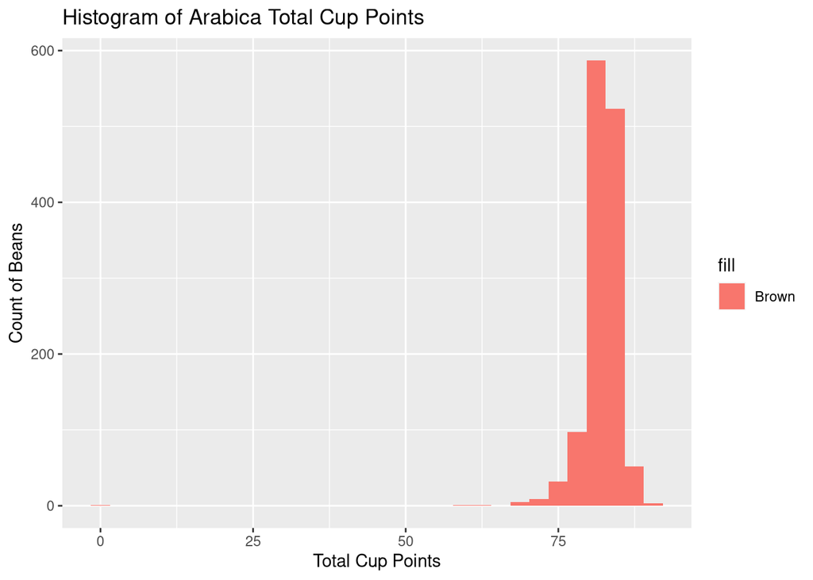

```r
ggplot(data = arabica_trimmed_data) +
  geom_histogram(mapping = aes(x = total_cup_points, fill = "Brown")) +
  labs(
    title = "Histogram of Arabica Total Cup Points",
    x = "Total Cup Points",
    y = "Count of Beans"
  )
```

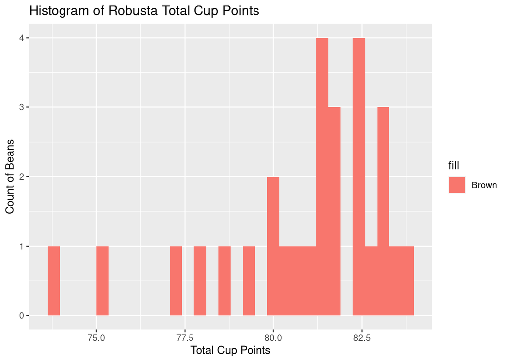

```r
ggplot(data = robusta_trimmed_data) +
  geom_histogram(mapping = aes(x = total_cup_points, fill = "Brown")) +
  labs(
    title = "Histogram of Robusta Total Cup Points",
    x = "Total Cup Points",
    y = "Count of Beans"
  )
```

Upon identifying outliers, I focused into the data to investigate the root causes and determine whether they should be retained or removed. This examination aims to provide understanding for informed decision-making in subsequent analyses.

11. Removing an outlier attributed to potential data entry error.

Upon review, it appears that one bean was scored incorrectly, receiving a score of zero due to an incomplete assessment. Consequently, I have opted to exclude it from the dataset to prevent potential distortion of the analysis results.

```r
arabica_trimmed_data <- arabica_trimmed_data %>%
  filter(total_cup_points > 0)
```

12. To dig deeper into the analysis, I decided to change the date from strings to a proper date format. But, some dates had words like “th” in them, like “April 4th, 2016.” So, I used a package called ‘stringr’ to capture only the numbers and then changed it into a proper date format using another package called ‘lubridate.’.

```r
arabica_trimmed_data$grading_date <-
  mdy(str_replace_all(arabica_trimmed_data$grading_date,
                      "\\b(\\d+)th\\b", "\\1"))
```

```r
robusta_trimmed_data$grading_date <-
  mdy(str_replace_all(robusta_trimmed_data$grading_date,
                      "\\b(\\d+)th\\b", "\\1"))
```

13. Combining both data frames in preparation for the overall analysis

```r
combined_coffee_data <- rbind(arabica_trimmed_data, robusta_trimmed_data)
```

14. Exporting csv file for safe keeping and further analysis

```r
write.csv(arabica_trimmed_data, "arabica_trimmed_data.csv", row.names = FALSE)
write.csv(robusta_trimmed_data, "robusta_trimmed_data.csv", row.names = FALSE)
write.csv(combined_coffee_data, "combined_coffee_data.csv", row.names = FALSE)
```

# Analysis Phase

### Preparation of the environment for analysis

So that I can transform data from wide to long format, I installed the reshape2 package.

```r
install.packages("reshape2")
library(reshape2)
```

### TASK 1: Identification of Key Quality Factor of a Coffee Bean

To identify the key quality factors significantly influencing the overall quality of a coffee bean, I employed correlation calculations between the sensory values of the coffee bean and the total cup points.

I decided to compare correlation between aroma, flavor, aftertaste, acidity, body, balance, uniformity, clean cup, sweetness, cupper points and total cup points. This will be applied to arabica, robusta and their combined data for further analysis.

```r
arabica_correlation_matrix <-
  cor(arabica_trimmed_data[, c(13:22, 23)])

robusta_correlation_matrix <-
  cor(robusta_trimmed_data[, c(13:22, 23)])

combined_correlation_matrix <-
  cor(combined_coffee_data[, c(13:22, 23)])
```

Melted correlation matrix for the 3 dataframes for visualization purposes

```r
arabica_melted_correlation <- melt(arabica_correlation_matrix)
robusta_melted_correlation <- melt(robusta_correlation_matrix)
combined_melted_correlation <- melt(combined_correlation_matrix)
```

To gain a deeper understanding of the data, I chose to visualize it using a heatmap. This allowed me to examine the strength of the correlation between each sensory value and the total cup points.

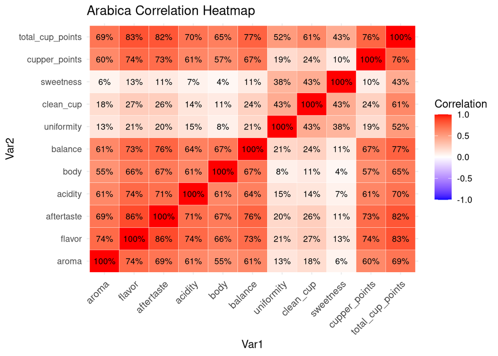

```r
ggplot(arabica_melted_correlation) +
  geom_tile(mapping = aes(Var1, Var2, fill = value), color = "white") +
  geom_text(aes(Var1, Var2, label = paste0(round(value * 100), "%")),
            size = 3) +
  labs(title = "Arabica Correlation Heatmap") +
  scale_fill_gradient2(low = "blue", high = "red", mid = "white",
                       midpoint = 0, limit = c(-1, 1), space = "Lab",
                       name = "Correlation") +
  theme_minimal() +
  theme(axis.text.x = element_text(angle = 45, vjust = 1, size = 10, hjust = 1))
```

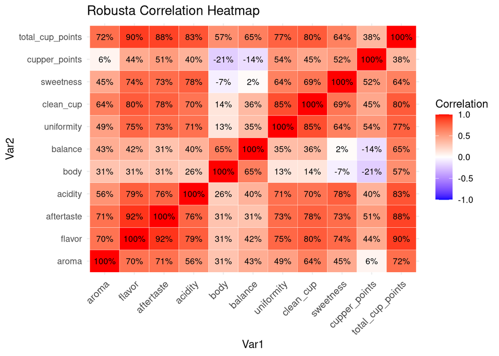

```r
ggplot(robusta_melted_correlation) +
  geom_tile(mapping = aes(Var1, Var2, fill = value), color = "white") +
  geom_text(aes(Var1, Var2, label = paste0(round(value * 100), "%")),
            size = 3) +
  labs(title = "Robusta Correlation Heatmap") +
  scale_fill_gradient2(low = "blue", high = "red", mid = "white",
                       midpoint = 0, limit = c(-1, 1), space = "Lab",
                       name = "Correlation") +
  theme_minimal() +
  theme(axis.text.x = element_text(angle = 45, vjust = 1, size = 10, hjust = 1))
```

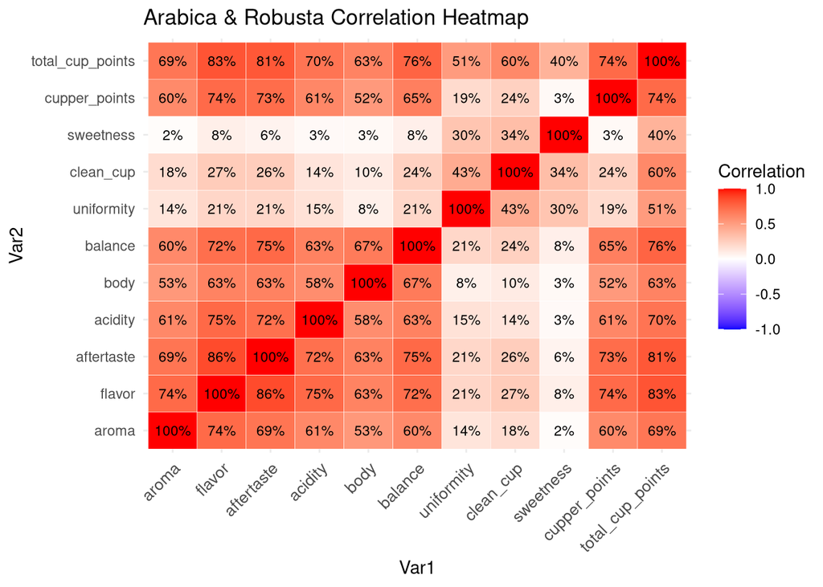

```r
ggplot(combined_melted_correlation) +
  geom_tile(mapping = aes(Var1, Var2, fill = value), color = "white") +
  geom_text(aes(Var1, Var2, label = paste0(round(value * 100), "%")),
            size = 3) +
  labs(title = "Arabica & Robusta Correlation Heatmap") +
  scale_fill_gradient2(low = "blue", high = "red", mid = "white",
                       midpoint = 0, limit = c(-1, 1), space = "Lab",
                       name = "Correlation") +
  theme_minimal() +
  theme(axis.text.x = element_text(angle = 45, vjust = 1, size = 10, hjust = 1))
```

### TASK 2: Analysis on the key difference between Arabica and Robusta

I calculated the mean values of each sensory quality for Arabica and Robusta beans, enabling a side-by-side comparison through visualization. Subsequently, results were consolidated into a single dataframe and were melted.

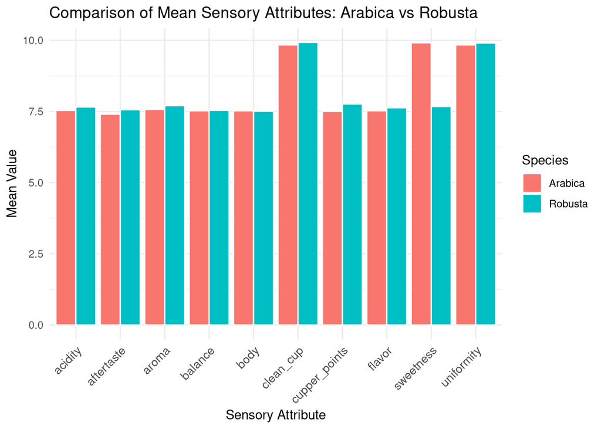

```r
mean_arabica <- colMeans(arabica_trimmed_data[, 13:22], na.rm = TRUE)
mean_robusta <- colMeans(robusta_trimmed_data[, 13:22], na.rm = TRUE)

mean_sensory_values <- data.frame(
  Attribute = names(mean_arabica),
  Arabica = mean_arabica,
  Robusta = mean_robusta
)

melted_mean_sensory <- melt(mean_sensory_values)

ggplot(data = melted_mean_sensory) +
  geom_bar(mapping = aes(x = Attribute, y = value, fill = variable),
           stat = "identity", position = "dodge", color = "white") +
  labs(title = "Comparison of Mean Sensory Attributes: Arabica vs Robusta",
       y = "Mean Value",
       x = "Sensory Attribute",
       fill = "Species") +
  theme_minimal() +
  theme(axis.text.x =  element_text(angle = 45, vjust = 1, size = 10,
                                    hjust = 1))
```

### TASK 3: Checking what countries that consistently produce higher-quality beans

To determine the leading producers of high-quality coffee, I computed the average total cup points for each country.

```r
arabica_quality_country <-
  aggregate(arabica_trimmed_data[, 13:23],
            by = list(country = arabica_trimmed_data$country_of_origin),
            FUN = mean)

robusta_quality_country <-
  aggregate(robusta_trimmed_data[, 13:23],
            by = list(country = robusta_trimmed_data$country_of_origin),
            FUN = mean)

combined_quality_country <-
  aggregate(combined_coffee_data[, 13:23],
            by = list(country = combined_coffee_data$country_of_origin),
            FUN = mean)

arabica_quality_country <-
  arabica_quality_country[order(-arabica_quality_country$total_cup_points), ]

robusta_quality_country <-
  robusta_quality_country[order(-robusta_quality_country$total_cup_points), ]

combined_quality_country <-
  combined_quality_country[order(-combined_quality_country$total_cup_points), ]
```

Following the calculation of average total cup points for each country, I proceeded to create a bar graph for a visual representation of the top-performing countries.

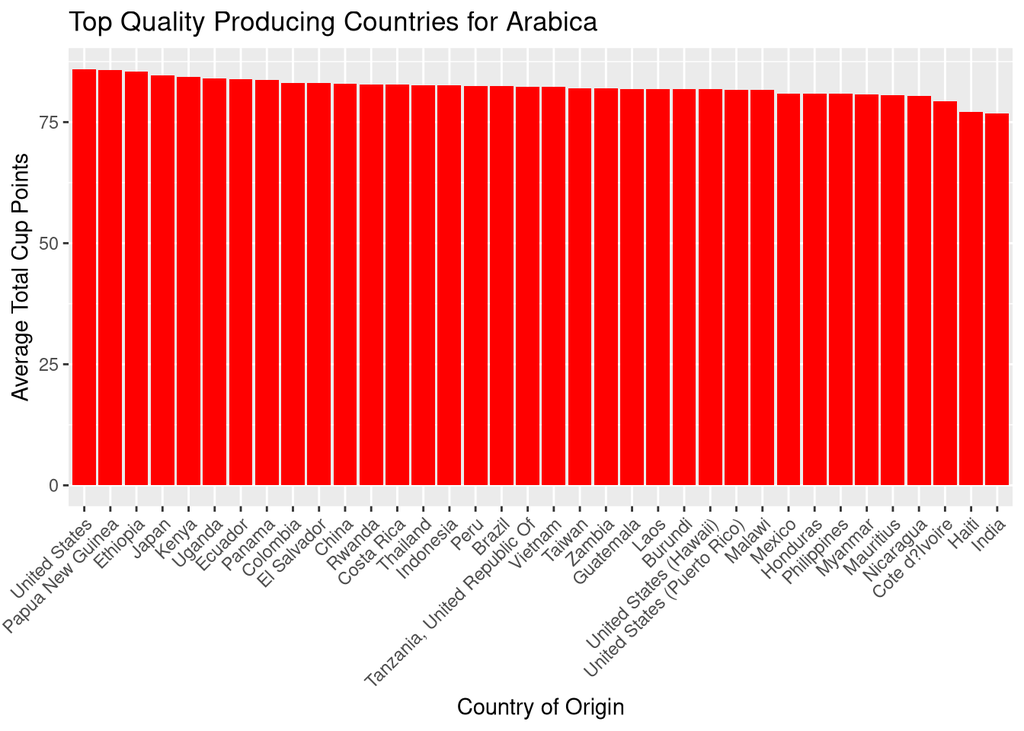

```r
# for arabica
ggplot(data = arabica_quality_country) +
  geom_bar(mapping = aes(x = reorder(country, -total_cup_points),
                         y = total_cup_points),
           stat = "identity", fill = "red") +
  labs(title = "Top Quality Producing Countries for Arabica",
       x = "Country of Origin",
       y = "Average Total Cup Points") +
  theme(axis.text.x = element_text(angle = 45, hjust = 1))
```

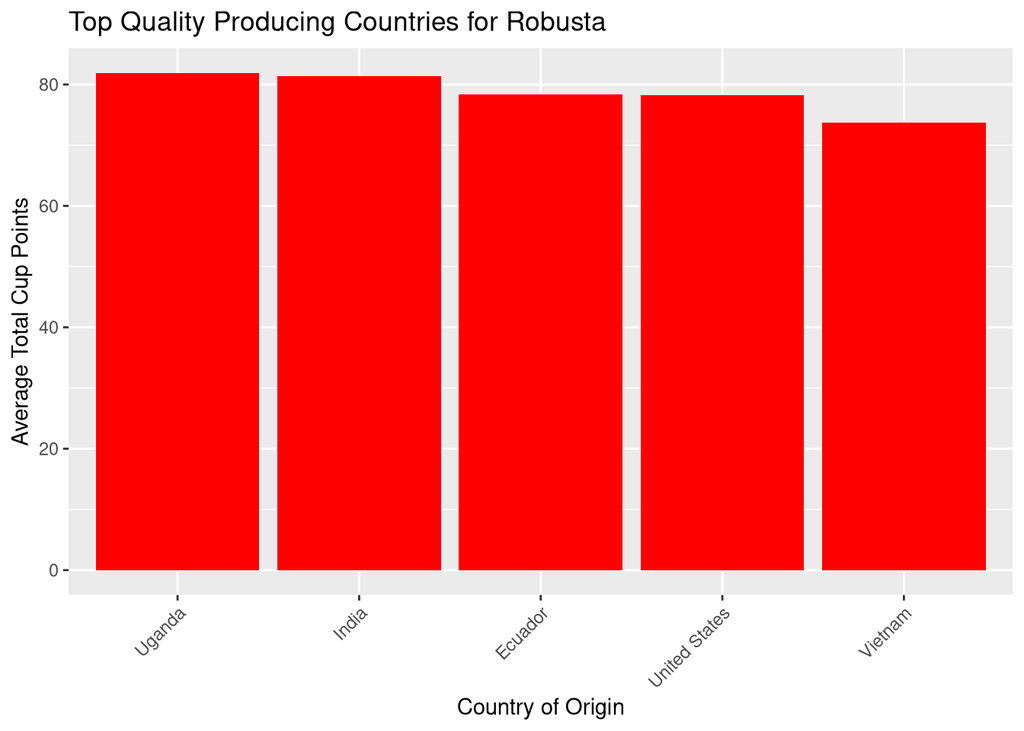

```r
# for robusta
ggplot(data = robusta_quality_country) +
  geom_bar(mapping = aes(x = reorder(country, -total_cup_points),
                         y = total_cup_points),
           stat = "identity", fill = "red") +
  labs(title = "Top Quality Producing Countries for Robusta",
       x = "Country of Origin",
       y = "Average Total Cup Points") +
  theme(axis.text.x = element_text(angle = 45, hjust = 1))
```

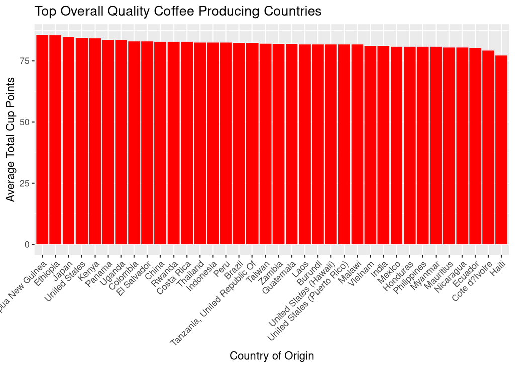

```r
# for combined data:
ggplot(data = combined_quality_country) +
  geom_bar(mapping = aes(x = reorder(country, -total_cup_points),
                         y = total_cup_points),
           stat = "identity", fill = "red") +
  labs(title = "Top Overall Quality Coffee Producing Countries",
       x = "Country of Origin",
       y = "Average Total Cup Points") +
  theme(axis.text.x = element_text(angle = 45, hjust = 1))
```

### TASK 4: Identifying Top Owners based on Top Countries

To identify the leading coffee producers within specific countries, I filtered the data frames for Arabica, focusing on the United States, Papua New Guinea, Ethiopia, Japan, and Kenya. Subsequently, I organized the results in descending order based on the mean total cup points. However, to gain insights into consistent high-quality coffee production by species, I chose to extract the top 10 owners irrespective of their respective countries.

```r
# Filtering the data based on the top countries producing arabica
filtered_arabica_country <- c("United States", "Papua New Guinea",
                              "Ethiopia", "Japan", "Kenya")

# Grouping owners by country
grouped_owners_arabica <- arabica_trimmed_data %>%
  filter(country_of_origin %in% filtered_arabica_country) %>%
  group_by(owner, country_of_origin) %>%
  summarise(mean_total_cup_points = mean(total_cup_points, na.rm = TRUE)) %>%
  arrange(-mean_total_cup_points)

grouped_owners_robusta <- robusta_trimmed_data %>%
  group_by(owner, country_of_origin) %>%
  summarise(mean_total_cup_points = mean(total_cup_points, na.rm = TRUE)) %>%
  arrange(-mean_total_cup_points)

# Identifying top 10 owners that produces quality coffee bean
top_owners_arabica <- head(grouped_owners_arabica, 10)
top_owners_robusta <- head(grouped_owners_robusta, 10)

print(top_owners_arabica)
```

```
## # A tibble: 10 × 3
## # Groups:   owner [10]
##    owner                           country_of_origin mean_total_cup_points
##    <chr>                           <chr>                             <dbl>
##  1 metad plc                       Ethiopia                           89.8
##  2 yidnekachew dabessa             Ethiopia                           89
##  3 diamond enterprise plc          Ethiopia                           88.2
##  4 mohammed lalo                   Ethiopia                           88.1
##  5 cqi q coffee sample representa… United States                      87.3
##  6 ji-ae ahn                       Ethiopia                           87.1
##  7 hider abamecha                  Ethiopia                           86.2
##  8 lusso lab                       Kenya                              86
##  9 ibrahim hussien speciality cof… Ethiopia                           85.8
## 10 colbran coffeelands, ltd.       Papua New Guinea                   85.8
```

```r
print(top_owners_robusta)
```

```
## # A tibble: 10 × 3
## # Groups:   owner [9]
##    owner                           country_of_origin mean_total_cup_points
##    <chr>                           <chr>                             <dbl>
##  1 katuka development trust ltd    Uganda                             83
##  2 ankole coffee producers coop    Uganda                             82.6
##  3 nishant gurjer                  India                              82.5
##  4 ugacof                          Uganda                             82.4
##  5 andrew hetzel                   India                              81.6
##  6 kasozi coffee farmers associat… Uganda                             81.5
##  7 kawacom uganda ltd              Uganda                             80.9
##  8 nitubaasa ltd                   Uganda                             80.6
##  9 mannya coffee project           Uganda                             80.5
## 10 andrew hetzel                   United States                      79.3
```

I utilized a bar graph for a visual examination of the top 10 coffee owners for each coffee bean specie.

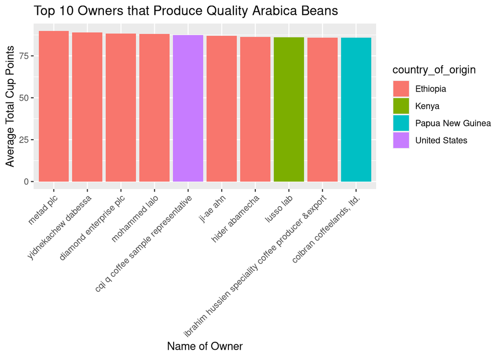

```r
# top 10 coffee owners for arabica
ggplot(data = top_owners_arabica) +
  geom_bar(mapping = aes(x = reorder(owner, -mean_total_cup_points),
                         y = mean_total_cup_points,
                         fill = country_of_origin),
           stat = "identity") +
  labs(title = "Top 10 Owners that Produce Quality Arabica Beans",
       x = "Name of Owner",
       y = "Average Total Cup Points") +
  theme(axis.text.x = element_text(angle = 45, hjust = 1))
```

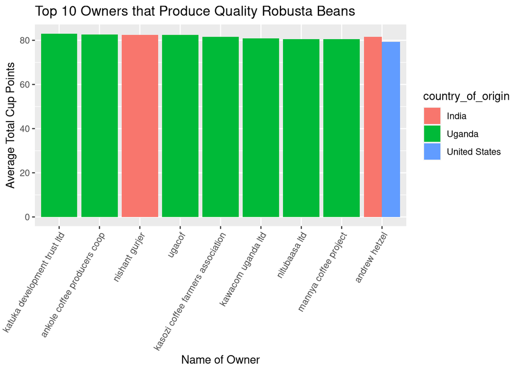

```r
# top 10 coffee owners for robusta
ggplot(data = top_owners_robusta) +
  geom_bar(mapping = aes(x = reorder(owner, -mean_total_cup_points),
                         y = mean_total_cup_points,
                         fill = country_of_origin),
           stat = "identity", position = "dodge") +
  labs(title = "Top 10 Owners that Produce Quality Robusta Beans",
       x = "Name of Owner",
       y = "Average Total Cup Points") +
  theme(axis.text.x = element_text(angle = 60, hjust = 1))
```

### TASK 5: Assessing whether the altitude at which coffee is grown has an impact on quality

In order to analyze the potential impact of altitude on the overall quality of a coffee bean, I calculated the correlation between all sensory values and the average altitude.

```r
# Calculating correlation between sensory values and altitude
altitude_correlation_arabica <-
  cor(na.omit(arabica_trimmed_data[, c(13:23, 31)]))

altitude_correlation_robusta <-
  cor(na.omit(robusta_trimmed_data[, c(13:23, 31)]))

# Melting data frame for use in ggplot
melted_altitude_arabica <- melt(altitude_correlation_arabica)
melted_altitude_robusta <- melt(altitude_correlation_robusta)
```

To visually explore the correlation between sensory values and average altitude, I created a heatmap.

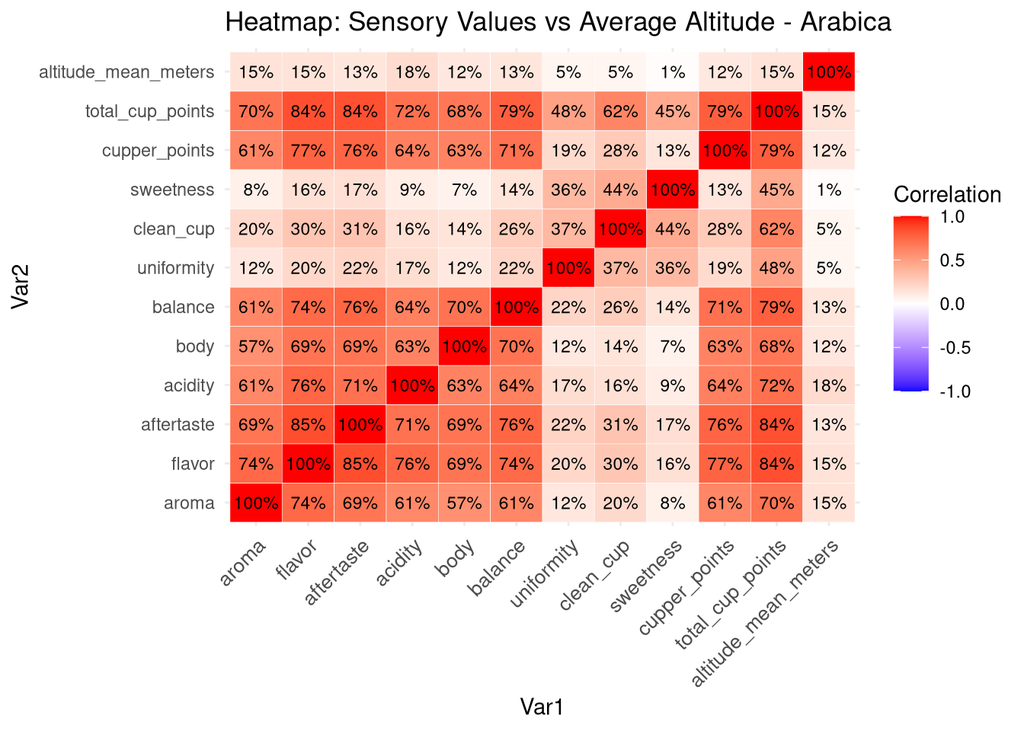

```r
ggplot(melted_altitude_arabica) +
  geom_tile(mapping = aes(Var1, Var2, fill = value), color = "white") +
  geom_text(aes(Var1, Var2, label = paste0(round(value * 100), "%")),
            size = 3) +
  labs(title = "Heatmap: Sensory Values vs Average Altitude - Arabica") +
  scale_fill_gradient2(low = "blue", high = "red", mid = "white",
                       midpoint = 0, limit = c(-1, 1), space = "Lab",
                       name = "Correlation") +
  theme_minimal() +
  theme(axis.text.x = element_text(angle = 45, vjust = 1, size = 10, hjust = 1))
```

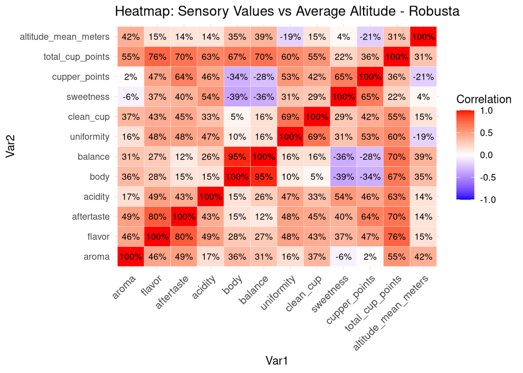

```r
ggplot(melted_altitude_robusta) +
  geom_tile(mapping = aes(Var1, Var2, fill = value), color = "white") +
  geom_text(aes(Var1, Var2, label = paste0(round(value * 100), "%")),
            size = 3) +
  labs(title = "Heatmap: Sensory Values vs Average Altitude - Robusta") +
  scale_fill_gradient2(low = "blue", high = "red", mid = "white",
                       midpoint = 0, limit = c(-1, 1), space = "Lab",
                       name = "Correlation") +
  theme_minimal() +
  theme(axis.text.x = element_text(angle = 45, vjust = 1, size = 10, hjust = 1))
```

To have other insights, I decided to visualize it through a scatterplot

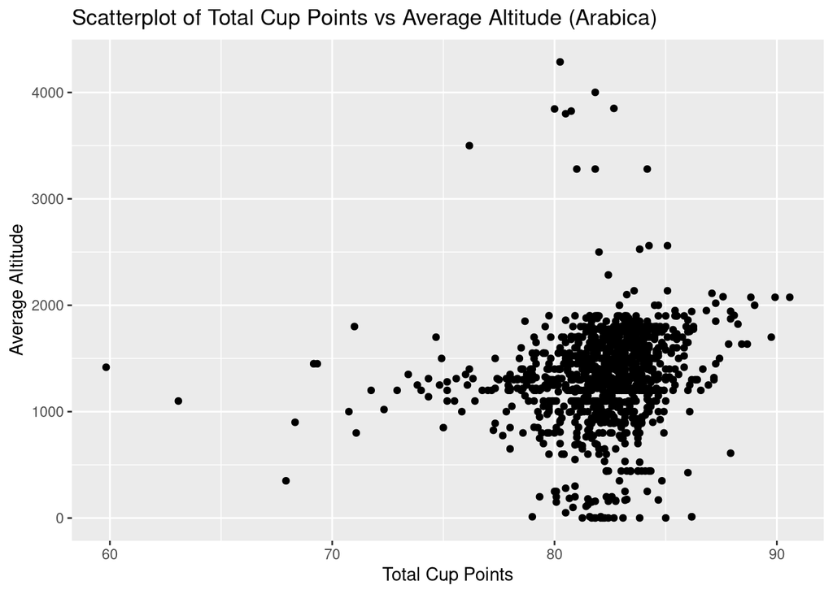

```r
# for arabica
ggplot(data = arabica_trimmed_data) +
  geom_point(mapping = aes(x = total_cup_points, y = altitude_mean_meters)) +
  labs(title = "Scatterplot of Total Cup Points vs Average Altitude (Arabica)",
       x = "Total Cup Points",
       y = "Average Altitude")
```

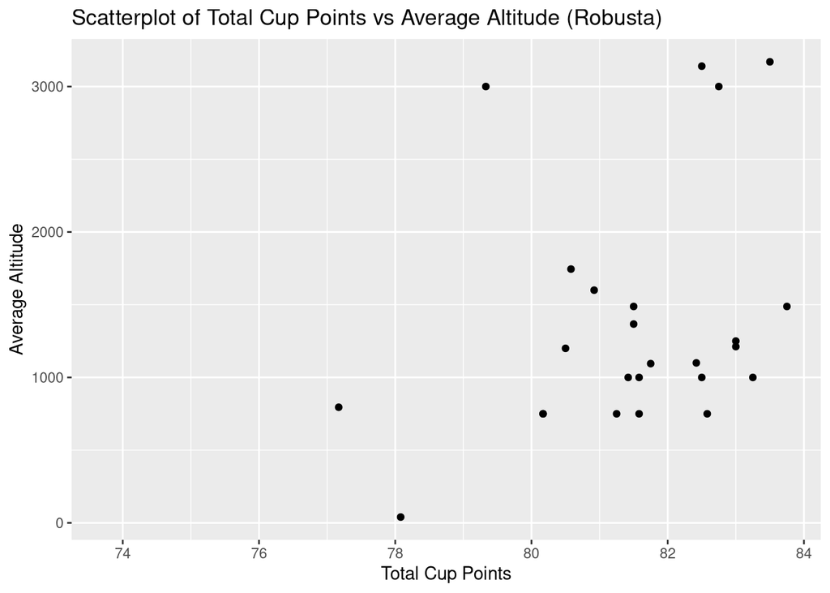

```r
# for robusta
ggplot(data = robusta_trimmed_data) +
  geom_point(mapping = aes(x = total_cup_points, y = altitude_mean_meters)) +
  labs(title = "Scatterplot of Total Cup Points vs Average Altitude (Robusta)",
       x = "Total Cup Points",
       y = "Average Altitude")
```

Following the analysis of the scatterplot results, I further examined the altitude ranges associated with the top 5 countries for both Arabica and Robusta. This additional investigation provides valuable insights into the elevation preferences associated with the production of high-quality coffee in these regions.

```r
# Analyzing what range of altitude does the top quality producing countries have
grouped_altitude_arabica <- arabica_trimmed_data %>%
  filter(country_of_origin %in% filtered_arabica_country) %>%
  group_by(country_of_origin) %>%
  summarise(AvgAltLow = mean(altitude_low_meters, na.rm = TRUE),
            AvgAltHigh = mean(altitude_high_meters, na.rm = TRUE),
            mean_total_cup_points = mean(total_cup_points, na.rm = TRUE)) %>%
  arrange(-mean_total_cup_points)

grouped_altitude_robusta <- robusta_trimmed_data %>%
  group_by(country_of_origin) %>%
  summarise(AvgAltLow = mean(altitude_low_meters, na.rm = TRUE),
            AvgAltHigh = mean(altitude_high_meters, na.rm = TRUE),
            mean_total_cup_points = mean(total_cup_points, na.rm = TRUE)) %>%
  arrange(-mean_total_cup_points)

print(grouped_altitude_arabica)
```

```
## # A tibble: 5 × 4
##   country_of_origin AvgAltLow AvgAltHigh mean_total_cup_points
##   <chr>                 <dbl>      <dbl>                 <dbl>
## 1 United States         1859.      1859.                  86.0
## 2 Papua New Guinea      1700       1700                   85.8
## 3 Ethiopia              1702.      1899.                  85.5
## 4 Japan                  170        170                   84.7
## 5 Kenya                 1466.      1539.                  84.3
```

```r
print(grouped_altitude_robusta)
```

```
## # A tibble: 5 × 4
##   country_of_origin AvgAltLow AvgAltHigh mean_total_cup_points
##   <chr>                 <dbl>      <dbl>                 <dbl>
## 1 Uganda                1330.      1380.                  81.9
## 2 India                 1422.      1422.                  81.4
## 3 Ecuador                 40         40                   78.4
## 4 United States         1898.      1898.                  78.2
## 5 Vietnam                NaN        NaN                   73.8
```